# 5205 final prj Q2 h1

ZiYan Cui

4/17/2023

```r
library(tidyverse)
library(tm)
library(tidytext)
library(dplyr)
library(wordcloud)
library(tidyr); library(ggplot2); library(ggthemes)

disneyland<- read.csv(file = "disneyland.csv", stringsAsFactors = F)
```

# Research Question 2

## Hypothesis 1:

H0: Reviews from different Disney branches tend to focus on similar topics.  
Ha: Reviews from different Disney branches focus on different topics.

```r
# split dataset based on branch
hongkong <- disneyland %>%
  filter(Branch == 'Disneyland_HongKong')
cali <- disneyland %>%
  filter(Branch == 'Disneyland_California')
paris <- disneyland %>%
  filter(Branch == 'Disneyland_Paris')
```

Splited the three branches based on location and examine the reviews in the following.

### Hong Kong

```r
hongkong$Review_Text <- gsub('Hong Kong','HongKong', hongkong$Review_Text)

# create corpus
corpus = Corpus(VectorSource(hongkong$Review_Text))
corpus[[1]][1]
```

```
## $content
## [1] "If you've ever been to Disneyland anywhere you'll find Disneyland HongKong very similar in the layout when you walk into main street! It has a very familiar feel. One of the rides  its a Small World  is absolutely fabulous and worth doing. The day we visited was fairly hot and relatively bus…
```

```r
# clean text
# convert to lower case
corpus = tm_map(corpus,FUN = content_transformer(tolower))

# remove urls
corpus = tm_map(corpus,
                FUN = content_transformer(FUN = function(x)gsub(pattern = 'http[[:alnum:][:punct:]]*',
                                                                replacement = ' ',x = x)))

# remove punctuations
corpus = tm_map(corpus,FUN = removePunctuation)
corpus[[1]][1]
```

```
## $content
## [1] "if youve ever been to disneyland anywhere youll find disneyland hongkong very similar in the layout when you walk into main street it has a very familiar feel one of the rides  its a small world  is absolutely fabulous and worth doing the day we visited was fairly hot and relatively busy but…
```

```r
# remove stopwords
corpus = tm_map(corpus,FUN = removeWords,c(stopwords('english')))
corpus[[1]][1]
```

```
## $content
## [1] " youve ever   disneyland anywhere youll find disneyland hongkong  similar   layout   walk  main street     familiar feel one   rides    small world   absolutely fabulous  worth   day  visited  fairly hot  relatively busy   queues moved fairly well "
```

```r
# strip white spaces
corpus = tm_map(corpus,FUN = stripWhitespace)
corpus[[1]][1]
```

```
## $content
## [1] " youve ever disneyland anywhere youll find disneyland hongkong similar layout walk main street familiar feel one rides small world absolutely fabulous worth day visited fairly hot relatively busy queues moved fairly well "
```

```r
# create dictionary
dict = findFreqTerms(DocumentTermMatrix(Corpus(VectorSource(disneyland$Review_Text))),
                     lowfreq = 0)
dict_corpus = Corpus(VectorSource(dict))

# stem document
corpus = tm_map(corpus,FUN = stemDocument)

# create document term matrix
dtm = DocumentTermMatrix(corpus)

# remove sparse terms
xdtm = removeSparseTerms(dtm,sparse = 0.97)
xdtm
```

```
## <<DocumentTermMatrix (documents: 9147, terms: 292)>>
## Non-/sparse entries: 234093/2436831
## Sparsity           : 91%
## Maximal term length: 10
## Weighting          : term frequency (tf)
```

```r
dim(xdtm)
```

```
## [1] 9147  292
```

```r
# make dataframe and complete stems
xdtm = as.data.frame(as.matrix(xdtm))
colnames(xdtm) = stemCompletion(x = colnames(xdtm),
                                dictionary = dict_corpus,
                                type='prevalent')
colnames(xdtm) = make.names(colnames(xdtm))
word_freq_hk <- data.frame(word = colnames(xdtm), freq = colSums(xdtm))


# word cloud
# set.seed(617)
# wordcloud(words = word_freq_hk$word,word_freq_hk$freq,scale=c(2,0.5),max.words = 100,colors=brewer.pal(9,"Spectral"))



word_total_hk = sum(word_freq_hk$freq)
hk_30 <- word_freq_hk %>%
  mutate(percentage = freq/word_total_hk*100) %>%
  arrange(desc(percentage)) %>%
  head(30)

# top 30 frequent words in Hong Kong
hk_30
```

```
##                  word freq percentage
## ride             ride 9138  3.0537055
## park             park 8088  2.7028201
## disneyland disneyland 7616  2.5450888
## day               day 7045  2.3542740
## disney         disney 6953  2.3235297
## time             time 5279  1.7641181
## visit           visit 4536  1.5158249
## one               one 3914  1.3079671
## kid               kid 3877  1.2956026
## show             show 3413  1.1405446
## get               get 3408  1.1388738
## place           place 3231  1.0797245
## hongkong     hongkong 3070  1.0259221
## food             food 2999  1.0021955
## can               can 2894  0.9671070
## enjoy           enjoy 2889  0.9654361
## parad           parad 2889  0.9654361
## great           great 2878  0.9617602
## good             good 2748  0.9183172
## will             will 2473  0.8264187
## just             just 2447  0.8177301
## like             like 2435  0.8137200
## queue           queue 2286  0.7639276
## attract       attract 2257  0.7542365
## small           small 2236  0.7472188
## fun               fun 2220  0.7418720
## firework     firework 2215  0.7402011
## realli         realli 2213  0.7395328
## wait             wait 2178  0.7278366
## love             love 2172  0.7258315
```

```r
#hk_30%>%
#  ggplot(aes(x=reorder(word,percentage), y=percentage, fill=percentage))+
#  geom_col(position='dodge')+
#  coord_flip()+
#  scale_fill_gradient2(low ="#FFEDF0", high = "#C84747",space ="Lab", guide = FALSE) +
#  theme_economist()+
#  theme(plot.background = element_blank())
```

The above result shows the top 30 frequent words in Hong Kong branch. There are words that are very common in this scenario but do not convey useful information, like ‘disneyland’, ‘disney’, ‘one’, and verbs like ‘get’, ‘can’, ‘will’, etc. Therefore, by manually filtering words that might convey more meaningful information, we would be able to know what topics do the reviewer care about when they visit to each branch.

#### Selected top 10 topics in Hong Kong

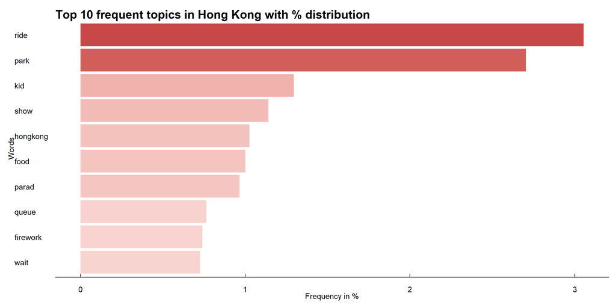

```r
hk_topwords <- subset(hk_30, rownames(hk_30) %in% c("ride", "park", "kid", "show", 'hongkong',
                                                    "food", "parad", "queue", "firework", "wait")) # 10 word
hk_topwords%>%
  ggplot(aes(x=reorder(word,percentage), y=percentage, fill=percentage))+
  geom_col(position='dodge')+
  coord_flip()+
  scale_fill_gradient2(low ="#FFEDF0", high = "#C84747",space ="Lab", guide = FALSE) +
  theme_economist()+
  theme(plot.background = element_blank()) +
  labs(x = "Words", y = "Frequency in %") +
  ggtitle("Top 10 frequent topics in Hong Kong with % distribution")
```

Above are the selected top 10 topics with frequency percentages for Hong Kong branch. We noticed that a considerable proportion of reviewers care about ride, the park itself, care about kid, the shows, etc. Looks like people tend to be excited about the Hong Kong branch itself. Following by food, parade, the queue and wait, as well as the firework. Looks like the top topics generally cover most of the facilities that are included in a typical Disneyland park.  
Next, we would use the same process to first generate top 30 frequent words for California branch and Paris branch, and then manually select meaningful topics that can provide insights.

### California

```r
# create corpus
corpus = Corpus(VectorSource(cali$Review_Text))
corpus[[1]][1]

# clean text
# convert to lower case
corpus = tm_map(corpus,FUN = content_transformer(tolower))

# remove urls
corpus = tm_map(corpus,
                FUN = content_transformer(FUN = function(x)gsub(pattern = 'http[[:alnum:][:punct:]]*',
                                                                replacement = ' ',x = x)))

# remove punctuations
corpus = tm_map(corpus,FUN = removePunctuation)
corpus[[1]][1]

# remove stopwords
corpus = tm_map(corpus,FUN = removeWords,c(stopwords('english')))
corpus[[1]][1]

# strip white spaces
corpus = tm_map(corpus,FUN = stripWhitespace)
corpus[[1]][1]

# create dictionary
dict = findFreqTerms(DocumentTermMatrix(Corpus(VectorSource(disneyland$Review_Text))),
                     lowfreq = 0)
dict_corpus = Corpus(VectorSource(dict))

# stem document
corpus = tm_map(corpus,FUN = stemDocument)

# create document term matrix
dtm = DocumentTermMatrix(corpus)

# remove sparse terms
xdtm = removeSparseTerms(dtm,sparse = 0.97)
xdtm
dim(xdtm)

# make dataframe and complete stems
xdtm = as.data.frame(as.matrix(xdtm))
colnames(xdtm) = stemCompletion(x = colnames(xdtm),
                                dictionary = dict_corpus,
                                type='prevalent')
colnames(xdtm) = make.names(colnames(xdtm))
word_freq_cali <- data.frame(word = colnames(xdtm), freq = colSums(xdtm))

# word cloud
# set.seed(617)
# wordcloud(words = word_freq_cali$word,word_freq_cali$freq,scale=c(2,0.5),max.words = 100,colors=brewer.pal(9,"Spectral"))

word_total_ca = sum(word_freq_cali$freq)
ca_30 <- word_freq_cali %>%
  mutate(percentage = freq/word_total_ca*100) %>%
  arrange(desc(percentage)) %>%
  head(30)
```

```r
# top 30 frequent topics in California
ca_30
```

```
##                  word  freq percentage
## park             park 21691  3.1450362
## ride             ride 20850  3.0230973
## time             time 16646  2.4135481
## disneyland disneyland 15329  2.2225928
## day               day 14834  2.1508214
## disney         disney 12237  1.7742754
## get               get 11930  1.7297626
## line             line  9061  1.3137787
## pass             pass  8027  1.1638562
## one               one  7739  1.1220983
## wait             wait  7580  1.0990445
## can               can  7244  1.0503270
## visit           visit  7217  1.0464122
## great           great  7024  1.0184286
## place           place  6596  0.9563717
## love             love  6263  0.9080891
## just             just  6233  0.9037394
## year             year  5859  0.8495121
## kid               kid  5837  0.8463223
## crowd           crowd  5738  0.8319680
## like             like  5303  0.7688962
## will             will  5227  0.7578767
## fast             fast  5201  0.7541069
## see               see  5073  0.7355479
## peopl           peopl  4628  0.6710261
## fun               fun  4603  0.6674013
## even             even  4481  0.6497122
## much             much  4469  0.6479723
## enjoy           enjoy  4399  0.6378228
## back             back  4301  0.6236135
```

```r
#ca_30%>%
#  ggplot(aes(x=reorder(word, percentage), y=percentage, fill=percentage))+
#  geom_col(position='dodge')+
#  coord_flip()+
#  scale_fill_gradient2(low ="#D6F1DF", high = "#00A632",space ="Lab", guide = FALSE) +
#  theme_economist()+
#  theme(plot.background = element_blank())
```

#### Selected top 10 topics in California

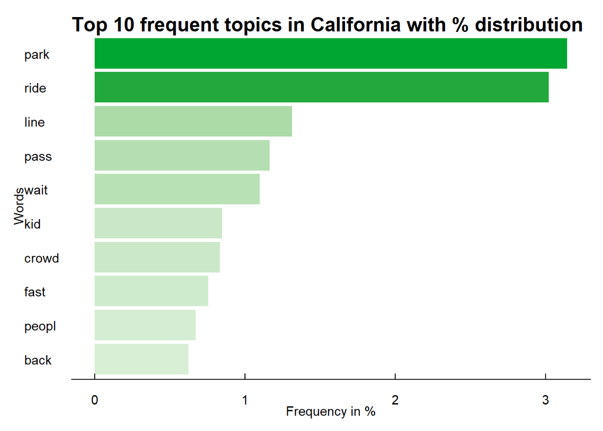

```r
ca_topwords <- subset(ca_30, rownames(ca_30) %in% c("park", "ride", "line", "pass", "wait",
                                                    "kid", "crowd", "fast", "peopl", "back")) # 10 words
ca_topwords %>%
  ggplot(aes(x=reorder(word, percentage), y=percentage, fill=percentage))+
  geom_col(position='dodge')+
  coord_flip()+
  scale_fill_gradient2(low ="#D6F1DF", high = "#00A632",space ="Lab", guide = FALSE) +
  theme_economist()+
  theme(plot.background = element_blank()) +
  labs(x = "Words", y = "Frequency in %") +
  ggtitle("Top 10 frequent topics in California with % distribution")
```

Above is the top 10 most frequent topics in California branch. Comparing to the Hong Kong branch, we could easily see that words like ‘line’, ‘pass’, ‘crowd’, ‘fast’, and ‘people’ occured on the list. This might suggest that people have more to say about their queue experiences, waiting time, about the visiting crowd or visitor amount, and probably the speed and efficiency taking rides during their visits.

### Paris

```r
# create corpus
corpus = Corpus(VectorSource(paris$Review_Text))
corpus[[1]][1]

# clean text
# convert to lower case
corpus = tm_map(corpus,FUN = content_transformer(tolower))

# remove urls
corpus = tm_map(corpus,
                FUN = content_transformer(FUN = function(x)gsub(pattern = 'http[[:alnum:][:punct:]]*',
                                                                replacement = ' ',x = x)))

# remove punctuations
corpus = tm_map(corpus,FUN = removePunctuation)
corpus[[1]][1]

# remove stopwords
corpus = tm_map(corpus,FUN = removeWords,c(stopwords('english')))
corpus[[1]][1]

# strip white spaces
corpus = tm_map(corpus,FUN = stripWhitespace)
corpus[[1]][1]

# create dictionary
dict = findFreqTerms(DocumentTermMatrix(Corpus(VectorSource(paris$Review_Text))),
                     lowfreq = 0)
dict_corpus = Corpus(VectorSource(dict))

# stem document
corpus = tm_map(corpus,FUN = stemDocument)

# create document term matrix
dtm = DocumentTermMatrix(corpus)

# remove sparse terms
xdtm = removeSparseTerms(dtm,sparse = 0.97)
xdtm
dim(xdtm)

# make dataframe and complete stems
xdtm = as.data.frame(as.matrix(xdtm))
colnames(xdtm) = stemCompletion(x = colnames(xdtm),
                                dictionary = dict_corpus,
                                type='prevalent')
colnames(xdtm) = make.names(colnames(xdtm))
word_freq_paris <- data.frame(word = colnames(xdtm), freq = colSums(xdtm))

# wordcloud
#set.seed(617)
#wordcloud(words = word_freq_paris$word,word_freq_paris$freq,scale=c(2,0.5),max.words = 100,colors=brewer.pal(9,"Spectral"))

word_total_pr = sum(word_freq_paris$freq)
pr_30 <- word_freq_paris %>%
  mutate(percentage = freq/word_total_ca*100) %>%
  arrange(desc(percentage)) %>%
  head(30)
```

```r
# top 30 frequent topics in Paris
pr_30
```

```
##          word  freq percentage
## 1        park 21527  3.1212574
## 2        ride 18419  2.6706201
## 3      disney 14422  2.0910844
## 4        time 13378  1.9397120
## 5         day 12148  1.7613711
## 6         get  9485  1.3752555
## 7         one  8172  1.1848802
## 8       queue  8167  1.1841552
## 9  disneyland  7417  1.0754107
## 10      visit  6822  0.9891400
## 11       just  6351  0.9208485
## 12        can  5997  0.8695211
## 13       food  5931  0.8599516
## 14       wait  5785  0.8387826
```

[output cut: 16 more lines]

```r
#pr_30%>%
#  ggplot(aes(x=reorder(word, percentage), y=percentage, fill=percentage))+
#  geom_col(position='dodge')+
#  coord_flip()+
#  scale_fill_gradient2(low ="#D4DFFF", high = "#4169E2",space ="Lab", guide = FALSE) +
#  theme_economist()+
#  theme(plot.background = element_blank())
```

#### Selected top 10 topics in Paris

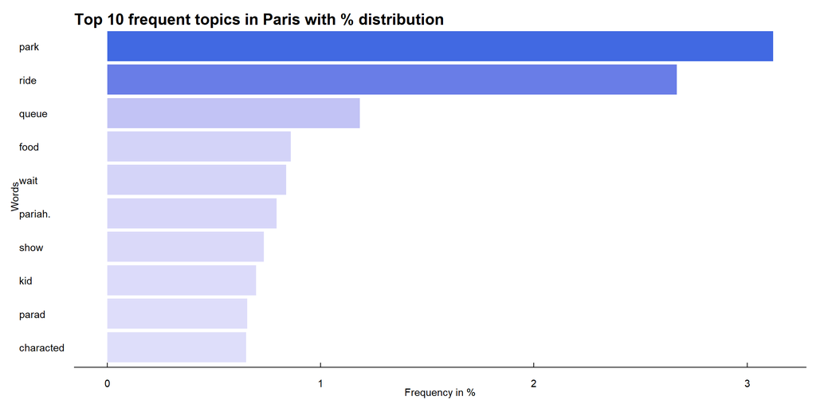

```r
pr_topwords <- subset(pr_30, rownames(pr_30) %in% c(1, 2, 8, 13, 14,
                                                    15, 18, 21, 27, 28)) # 10 words
pr_topwords %>%
  ggplot(aes(x=reorder(word, percentage), y=percentage, fill=percentage))+
  geom_col(position='dodge')+
  coord_flip()+
  scale_fill_gradient2(low ="#D4DFFF", high = "#4169E2",space ="Lab", guide = FALSE) +
  theme_economist()+
  theme(plot.background = element_blank()) +
  labs(x = "Words", y = "Frequency in %") +
  ggtitle("Top 10 frequent topics in Paris with % distribution")
```

```r
head(paris[grep("pariah", paris$Review_Text, ignore.case = TRUE), "Review_Text"], 2)
```

```
## [1] "Currently on holiday at Eurodisney. Have been to Disney in Florida numerous times, although extremely busy in high season the USA staff are courteous, friendly and efficient. Eurodisney is pleasant and spotless. But Oh! The service! There are practically no guides or attendants to assist you…
## [2] "It was a living hell.I took 2 trained carers and a severely mentally handicapped adult. It was a special once in a lifetime treat so stayed in the very expensive Disneyland Hotel. Took in doctors letter detailing ALL his medical problems. The staff in City Hall gave us a pass and explained h…
```

```r
head(paris[grep("character", paris$Review_Text, ignore.case = TRUE), "Review_Text"], 2)
```

```
## [1] "3rd time hereIt gets betterPlenty to do for allShopping Meet the Character'sRoller coasters and finish off with the fireworks display at 10 beside the castleSpace Mountain and Rockin roller coaster highly recomended or if you have the nerve tower of terror"
## [2] "Its a shame this park carry the name Disney... They build the place years back and they are now just collecting cash without any effort, it does not compare in anything with the American parks which are truly amazing. The whole park now is designed to get money from their guests on every ste…
```

Taking closer look at the reviews, we noticed that the reviewer who mentioned ‘pariah’ mostly talked about how they were treated like ‘pariah’ in some cases, some suggested otherwise. This might suggest that the customer services might be considered as polarized. For the ‘character’ word, this might suggest that visitors who went to Paris branch pay considerable attention to meeting with the characters in the park.

### Same frequent topics in all three branches

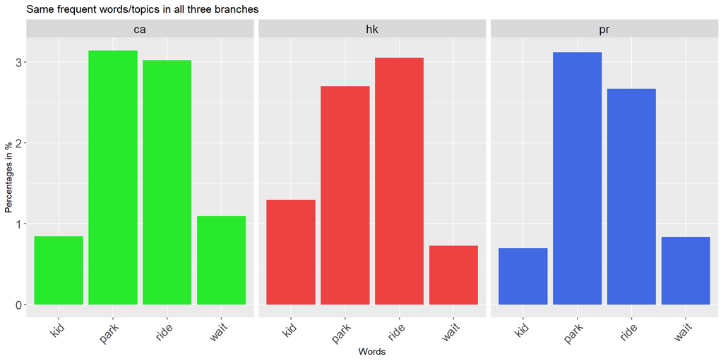

```r
hk_sub <- filter(hk_topwords,
                 word %in% c('park', 'ride', 'wait', 'kid'))%>% mutate(branch = 'hk')

ca_sub <- filter(ca_topwords,
                 word %in% c('park', 'ride', 'wait', 'kid'))%>% mutate(branch = 'ca')

pr_sub <- filter(pr_topwords,
                 word %in% c('park', 'ride', 'wait', 'kid'))%>% mutate(branch = 'pr')

same_topwords = rbind(hk_sub, ca_sub, pr_sub)
same_topwords <- same_topwords %>%
  select(word, percentage, branch)

ggplot(same_topwords, aes(x = word, y = percentage, fill = branch)) +
  geom_bar(stat = "identity", position = "dodge") +
  facet_wrap(~ branch, ncol = 3) +
  labs(x = "Words", y = "Percentages in %", fill = "Branch") +
  theme(plot.background = element_blank(),
        #text=element_text(size=16),
        strip.text=element_text(size=14),
        axis.text.x=element_text(size=14, angle=45, hjust=1),
        axis.text.y=element_text(size=14),
        legend.position = "none") +
  scale_fill_manual(values = c("hk" = "#EE4242", "ca" = "#28E92C", "pr" = "#4169E2", guide = FALSE)) +
  ggtitle("Same frequent words/topics in all three branches")
```

These words, ‘kid’, ‘park’, ‘ride’, and ‘wait’ are topics that are mentioned for all three branches. These might suggest that reviewers care about these topics regardless of the branch locations.